# Multi-Path Stepwise Selection with AIC: Runnable Examples

Han Xiu, Fritzner Pierre, Lauren Cooper

2025-12-04

# 1. Package and repository

This HTML file demonstrates the main functionality of our package for the final project **“Multi-Path Stepwise Selection with AIC”**.

- **GitHub repository name** (under `R-4-Data-Science`):  
  Package repository (final submitted package): model_selection_13  
  Project repository (development work): Final_Project_13
- **Repository link**:  
  Package repository: https://github.com/R-4-Data-Science/model_selection_13  
  Project repository: https://github.com/R-4-Data-Science/Final_Project_13

```r
Sys.setenv(LANG = "en")

# This chunk shows how to install the package from GitHub.
remotes::install_github("R-4-Data-Science/model_selection_13")
Sys.setenv(LANG = "en")

# Load the package
library(modelselection13)
```

# 2. Overview of the workflow

In this document, we show:

1. **A Gaussian (linear regression) example**:
   - Simulate data with a few truly important predictors
   - Run `build_paths()` to construct a multi-path model forest
   - Run `stability()` to estimate variable-level stability
   - Run `plausible_models()` to obtain a set of final plausible models
2. **A Binomial (logistic regression) example**:
   - Simulate binary outcome data
   - Run the same three functions
   - Use `confusion_metrics()` on a simple train/test split

We also briefly justify our default choices for the main tuning parameters  
$K, \varepsilon, \delta, L, B, \Delta, \tau$.

## 2.1 Linear regression (Gaussian family)

### 2.1.1 Simulate data and inspect single-variable AICs

We simulate a small dataset with $n = 120$ observations and $p = 8$ predictors. Only $x_1$, $x_2$ and $x_5$ are truly important.

```r
set.seed(1)
n <- 120
p <- 8

X <- matrix(rnorm(n * p), n, p)
beta <- c(2, -1.5, 0, 0, 1, rep(0, p - 5))
y <- as.vector(X %*% beta + rnorm(n, sd = 1))
colnames(X) <- paste0("x", 1:p)

df_lin <- data.frame(y = y, X)
str(df_lin)
```

```
## 'data.frame':    120 obs. of  9 variables:
##  $ y : num  -1.65 -2.81 -4.38 5.31 1.67 ...
##  $ x1: num  -0.626 0.184 -0.836 1.595 0.33 ...
##  $ x2: num  -0.506 1.343 -0.215 -0.18 -0.1 ...
##  $ x3: num  0.707 1.034 0.223 -0.879 1.163 ...
##  $ x4: num  -2.592 1.314 -0.636 -0.43 -0.169 ...
##  $ x5: num  -0.357 -1.147 -0.517 -0.362 2.351 ...
##  $ x6: num  -0.341 1.502 0.528 0.542 -0.137 ...
##  $ x7: num  0.4893 -0.7789 1.7436 -0.0784 -0.9756 ...
##  $ x8: num  2.006 -2.071 3.056 -0.261 -0.454 ...
```

Before using the multi-path algorithm, we can effciently compare **single-variable** models by AIC:

```r
# Intercept-only model AIC
fit_empty <- lm(y ~ 1, data = df_lin)
aic_empty <- AIC(fit_empty)

# One-variable models
cand_lm <- lapply(seq_len(p), function(j) {
  varname <- colnames(X)[j]
  lm(as.formula(paste0("y ~ ", varname)), data = df_lin)
})
aics <- sapply(cand_lm, AIC)

aic_table <- data.frame(
  variable = colnames(X),
  AIC      = aics
)

aic_table[order(aic_table$AIC), ][1:5, ]
```

```
##   variable      AIC
## 1       x1 535.5318
## 2       x2 556.3635
## 5       x5 581.5423
## 3       x3 596.4350
## 7       x7 599.4055
```

We expect the truly important variables (`x_1`, `x_2`, `x_5`) to appear near the top.

### 2.1.2 Multi-path forward selection with `build_paths()`

Now we run the full multi-path forward selection on the dataset using the **Gaussian** family.

Parameter choices (roughly following the project guidelines):

- $K = \min(p, 10) = 8$: maximum model size
- $\varepsilon = 10^{-6}$: minimal AIC improvement to expand a parent
- $\delta = 1$: keep children within 1 AIC of the best child per parent
- $L = 50$: cap on the number of models per step

```r
K_val    <- min(ncol(X), 10)
eps_val  <- 1e-6
delta_val<- 1
L_val    <- 50

forest_lin <- build_paths(
  x      = X,
  y      = y,
  family = "gaussian",
  K      = K_val,
  eps    = eps_val,
  delta  = delta_val,
  L      = L_val
)

# Inspect the overall AIC table
head(forest_lin$aic_by_model[order(forest_lin$aic_by_model$aic), ], 10)
```

```
##   step model_id               key      aic size       parent         vars
## 5    4        1 x1 + x2 + x5 + x7 357.0280    4 x1 + x2 + x5 x1, x2, ....
## 4    3        1      x1 + x2 + x5 362.7892    3      x1 + x2   x1, x2, x5
## 3    2        1           x1 + x2 433.7678    2           x1       x1, x2
## 2    1        1                x1 535.5318    1      <empty>           x1
## 1    0        1           <empty> 600.6662    0         <NA>
```

We can see how many models were kept at each step:

```r
sapply(forest_lin$frontiers, nrow)
```

```
## [1] 1 1 1 1 1
```

### 2.1.3 Stability estimation with `stability()`

Next, we compute **resampling-based stability** using bootstrap resampling and run `build_paths()` on each bootstrap sample. For each predictor $j$, we record the proportion of models on that resample containing $j$, then average over all resamples to obtain $\pi_j$.

Parameter choices:

- $B = 50$: number of resamples
- Resampling type: `"bootstrap"`

We keep the same $K, \varepsilon, \delta, L$ as in the full-data search.

```r
B_val <- 50

stab_lin <- stability(
  x        = X,
  y        = y,
  B        = B_val,
  resample = "bootstrap",
  family   = "gaussian",
  K        = K_val,
  eps      = eps_val,
  delta    = delta_val,
  L        = L_val
)

stab_lin$pi
```

```
##         x1         x2         x3         x4         x5         x6         x7
## 0.96438095 0.82456349 0.09142857 0.09093651 0.60588889 0.07666667 0.32126190
##         x8
## 0.12158730
```

We expect truly important predictors (`x1`, `x2`, `x5`) to have larger stability scores.

### 2.1.3 Plausible models with `plausible_models()`

We combine the full-data model forest with the stability scores to identify **plausible models**.

A model is considered plausible if:

1. Its AIC is within $\Delta$ of the best AIC in the forest:  
   $\mathrm{AIC} \le \mathrm{AIC}_{\min} + \Delta$
2. Its average stability $\pi(\mathcal{S})$ exceeds a threshold $\tau$:  
   $\pi(\mathcal{S}) = \frac{1}{|\mathcal{S}|} \sum_{j \in \mathcal{S}} \pi_j \ge \tau$

Typical choices:

- $\Delta = 2$: standard AIC “equivalence” window
- $\tau = 0.6$: require models to be built mostly from stable predictors

```r
Delta_val <- 2
tau_val   <- 0.6

plaus_lin <- plausible_models(
  forest = forest_lin,
  pi     = stab_lin$pi,
  Delta  = Delta_val,
  tau    = tau_val
)

plaus_lin
```

```
##   model_id               key step size     aic mean_stability         vars
## 5        1 x1 + x2 + x5 + x7    4    4 357.028      0.6790238 x1, x2, ....
##         parent
## 5 x1 + x2 + x5
```

We can inspect the variables with highest average stability across plausible models:

```r
if (nrow(plaus_lin) > 0) {
  # Extract union of variables across plausible models
  vars_all <- sort(unique(unlist(plaus_lin$vars)))
  vars_all
}
```

```
## [1] "x1" "x2" "x5" "x7"
```

## 2.2 Logistic regression (Binomial family)

Now we repeat the same workflow for a **binary outcome** with logistic regression.

### 2.2.1 Simulate binary data and inspect single-variable AICs

We simulate data with $n = 200$, $p = 6$, and a logistic link. Only `x_1`, `x_2`, and `x_5` have non-zero coefficients.

```r
set.seed(2)
n_b <- 200
p_b <- 6

Xb <- matrix(rnorm(n_b * p_b), n_b, p_b)
linpred <- 1.2 * Xb[, 1] - 1.0 * Xb[, 2] + 0.8 * Xb[, 5]
prob_true <- 1 / (1 + exp(-linpred))
ybin <- rbinom(n_b, size = 1, prob = prob_true)

colnames(Xb) <- paste0("x", 1:p_b)
df_logit <- data.frame(y = ybin, Xb)
str(df_logit)
```

```
## 'data.frame':    200 obs. of  7 variables:
##  $ y : int  0 0 0 0 1 0 1 1 1 0 ...
##  $ x1: num  -0.8969 0.1848 1.5878 -1.1304 -0.0803 ...
##  $ x2: num  0.298 -1.02 2.871 0.219 -0.967 ...
##  $ x3: num  -0.214 -2.722 -1.014 -0.829 0.858 ...
##  $ x4: num  -1.115 -0.114 -0.895 -0.654 1.179 ...
##  $ x5: num  -0.629 -2.2743 0.3349 -0.2137 -0.0315 ...
##  $ x6: num  0.4662 0.9547 -0.9472 0.0386 -0.8309 ...
```

Single-variable AIC comparison:

```r
fit0 <- glm(y ~ 1, family = binomial(), data = df_logit)
aic0 <- AIC(fit0)

fits1 <- lapply(seq_len(p_b), function(j) {
  varname <- colnames(Xb)[j]
  glm(as.formula(paste0("y ~ ", varname)),
      family = binomial(), data = df_logit)
})
aics1 <- sapply(fits1, AIC)

aic_table_logit <- data.frame(
  variable = colnames(Xb),
  AIC      = aics1
)

aic_table_logit[order(aic_table_logit$AIC), ][1:5, ]
```

```
##   variable      AIC
## 1       x1 241.0645
## 2       x2 259.7280
## 5       x5 264.4910
## 4       x4 277.2297
## 3       x3 278.2347
```

### 2.2.2 Multi-path forward selection for logistic regression

We build the multi-path forest using the **binomial** family.

```r
K_logit     <- min(ncol(Xb), 10)
eps_logit   <- 1e-6
delta_logit <- 1
L_logit     <- 50

forest_logit <- build_paths(
  x      = Xb,
  y      = ybin,
  family = "binomial",
  K      = K_logit,
  eps    = eps_logit,
  delta  = delta_logit,
  L      = L_logit
)

head(forest_logit$aic_by_model[order(forest_logit$aic_by_model$aic), ], 10)
```

```
##   step model_id               key      aic size       parent         vars
## 5    4        1 x1 + x2 + x3 + x5 197.9562    4 x1 + x2 + x5 x1, x2, ....
## 4    3        1      x1 + x2 + x5 198.5757    3      x1 + x2   x1, x2, x5
## 3    2        1           x1 + x2 217.9961    2           x1       x1, x2
## 2    1        1                x1 241.0645    1      <empty>           x1
## 1    0        1           <empty> 277.6367    0         <NA>
```

### 2.2.3 Stability estimation for logistic models

```r
B_logit <- 50

stab_logit <- stability(
  x        = Xb,
  y        = ybin,
  B        = B_logit,
  resample = "bootstrap",
  family   = "binomial",
  K        = K_logit,
  eps      = eps_logit,
  delta    = delta_logit,
  L        = L_logit
)

stab_logit$pi
```

```
##         x1         x2         x3         x4         x5         x6
## 0.94633333 0.66895238 0.14371429 0.05009524 0.59014286 0.06371429
```

### 2.3.4 Plausible logistic models

```r
Delta_logit <- 2
tau_logit   <- 0.6

plaus_logit <- plausible_models(
  forest = forest_logit,
  pi     = stab_logit$pi,
  Delta  = Delta_logit,
  tau    = tau_logit
)

plaus_logit
```

```
##   model_id          key step size      aic mean_stability       vars  parent
## 4        1 x1 + x2 + x5    3    3 198.5757      0.7351429 x1, x2, x5 x1 + x2
```

## 2.3 Simple train/test evaluation with `confusion_metrics()`

For the logistic example, we can perform a simple train/test split and evaluate performance of a single model (for example, the “best” plausible model or just a standard logistic regression).

```r
set.seed(28)
n_total <- nrow(df_logit)
train_idx <- sample.int(n_total, size = floor(0.7 * n_total))

train_dat <- df_logit[train_idx, ]
test_dat  <- df_logit[-train_idx, ]

# Simple logistic model with all predictors
fit_full <- glm(y ~ ., family = binomial(), data = train_dat)

# Predicted probabilities on test set
prob_test <- predict(fit_full, newdata = test_dat, type = "response")

# Confusion matrix and metrics at cutoff 0.5
cm <- confusion_metrics(test_dat$y, prob_test, cutoff = 0.5)

cm$confusion
```

```
##         predicted
## observed  0  1
##        0 29  8
##        1  5 18
```

```r
cm$metrics
```

```
##  prevalence    accuracy sensitivity specificity         FDR         DOR
##   0.3833333   0.7833333   0.7826087   0.7837838   0.3076923  13.0500000
```

## 2.4 Parameter choices and brief justification

For both the Gaussian and binomial examples, we used the following typical parameter values, following the project notes:

- $K = \min(p, 10)$: allows models up to a reasonable size without exploding the search
- $\varepsilon = 10^{-6}$: ensures we only expand models when there is at least a tiny AIC improvement
- $\delta = 1$: keeps near-ties within 1 AIC of the best child, which is a common AIC window
- $L = 50$: prevents the number of models per step from growing too large
- $B = 50$: provides a reasonable stability estimate without too much computation
- $\Delta = 2$: AIC tolerance for “statistically indistinguishable” models
- $\tau = 0.6$: requires models to be built mostly from predictors that appear frequently in resamples

Together, these values give a practical compromise between **exploration** (multiple near-best paths) and **stability** (resampling-based proportions).

# 3. Overlap heatmap and branching structure

The project description suggests two optional extras:  
(1) an **overlap heatmap of plausible models**  
(2) a **helper to visualize branching by step**

In this section, We use package functions `plot_heatmap()` and `plot_branching()` to illustrate both on the simulated Gaussian example.

```r
## ------------------------------------------------------------
## 1. Simulate a small linear regression dataset
## ------------------------------------------------------------

set.seed(28)

n <- 150   # number of observations
p <- 7     # number of predictors

# Design matrix
X <- matrix(rnorm(n * p), n, p)
colnames(X) <- paste0("x", 1:p)

# True coefficients: only x1, x3, x5 matter
beta_true <- c(2.0, 0, -1.5, 0, 1.2, rep(0, p - 5))

# Generate response with Gaussian noise
y <- as.vector(X %*% beta_true + rnorm(n, sd = 1))

## ------------------------------------------------------------
## 2. Run multi-path forward selection on this dataset
## ------------------------------------------------------------

K_val     <- min(p, 10)  # maximum model size
eps_val   <- 1e-6        # minimum AIC improvement
delta_val <- 1           # AIC tolerance for near-ties
L_val     <- 40          # max models per step

forest <- build_paths(
  x      = X,
  y      = y,
  family = "gaussian",
  K      = K_val,
  eps    = eps_val,
  delta  = delta_val,
  L      = L_val
)

# Quick check: number of models per step
sapply(forest$frontiers, nrow)
```

```
## [1] 1 1 1 1 1
```

```r
## ------------------------------------------------------------
## 3. Compute stability on resamples
## ------------------------------------------------------------

B_val <- 40  # number of resamples

stab <- stability(
  x        = X,
  y        = y,
  B        = B_val,
  resample = "bootstrap",
  family   = "gaussian",
  K        = K_val,
  eps      = eps_val,
  delta    = delta_val,
  L        = L_val
)

stab$pi  # stability scores per predictor
```

```
##         x1         x2         x3         x4         x5         x6         x7
## 1.00000000 0.13982143 0.74181548 0.07029762 0.48363095 0.05675595 0.04071429
```

```r
## ------------------------------------------------------------
## 4. Get plausible models from forest + stability
## ------------------------------------------------------------

Delta_val <- 4    # AIC tolerance for plausibility
tau_val   <- 0.5  # minimum average stability

plaus <- plausible_models(
  forest = forest,
  pi     = stab$pi,
  Delta  = Delta_val,
  tau    = tau_val
)

cat("Number of plausible models:", nrow(plaus), "\n")
```

```
## Number of plausible models: 2
```

```r
plaus
```

```
##   model_id               key step size      aic mean_stability         vars
## 4        1      x1 + x3 + x5    3    3 426.3256      0.7418155   x1, x3, x5
## 5        2 x1 + x2 + x3 + x5    4    4 425.9481      0.5913170 x1, x2, ....
##         parent
## 4      x1 + x3
## 5 x1 + x3 + x5
```

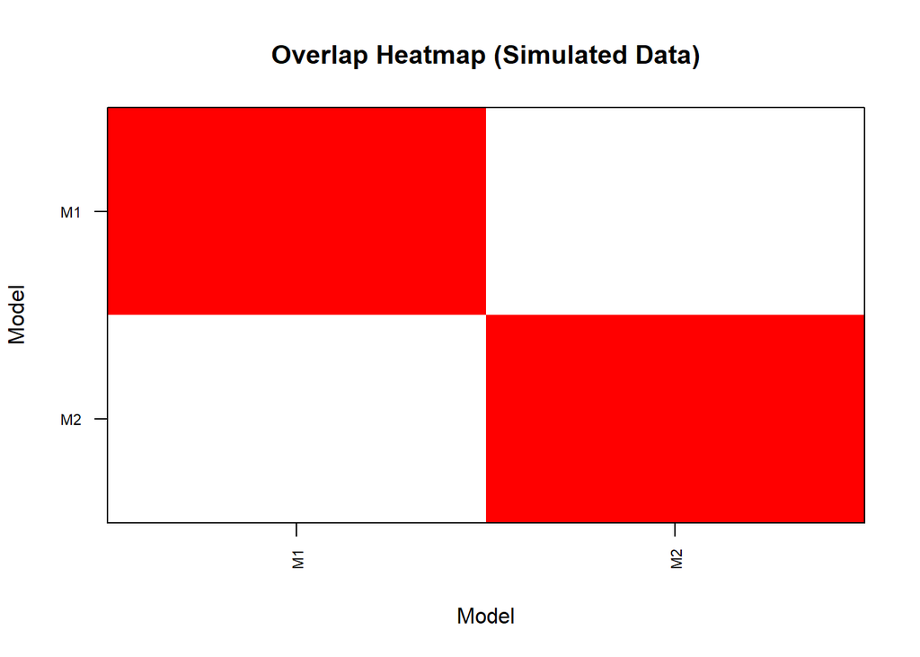

```
##      [,1] [,2]
## [1,] 1.00 0.75
## [2,] 0.75 1.00
```

```r
## ------------------------------------------------------------
## 5. Test plot_heatmap() on the plausible model set
## ------------------------------------------------------------

# This will draw a Jaccard-overlap heatmap between plausible models
if (nrow(plaus) >= 2) {
  jac_mat <- plot_heatmap(
    plaus,
    reorder = TRUE,
    main = "Overlap Heatmap (Simulated Data)"
  )
  print(jac_mat)
} else {
  message("Still not enough plausible models (need >= 2). ",
          "Try increasing Delta or decreasing tau further.")
}
```

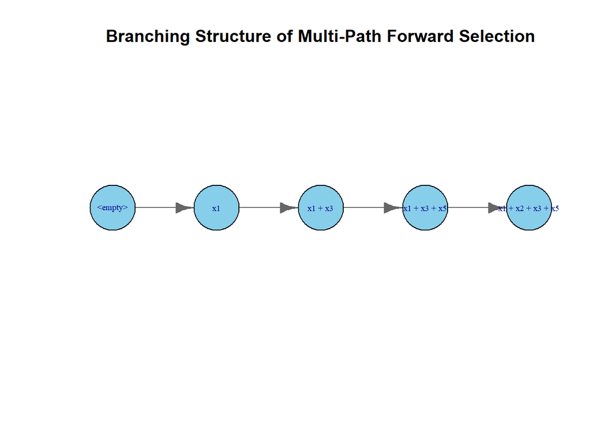

```r
## ------------------------------------------------------------
## 6. Test plot_branching() on the path forest
## ------------------------------------------------------------

# This will draw the branching structure across steps
plot_branching(
  forest,
  vertex_size  = 22,
  vertex_color = "skyblue",
  edge_color   = "gray40",
  label_cex    = 0.6
)
```